# Regression Attempts

Brooke Cummins, Andy Turner, Sean Bellevue and Jordan Gropper

2022-08-09

```r
library(fixest)
library(ggplot2)
library(tidyverse)
library(vtable)
library(Ecdat)
library(ggstance)
library(multcomp)
library(NHANES)
library(corrplot)
library(patchwork)
library(haven)
library(marginaleffects)
```

```r
clean_df<- read_csv('../RawData/final_clean.csv')
```

```
## ──────────────────────────────────────────────────────── Delimiter: "," chr
## (12): REGION, SEX, RACE, MARST, CLASSWKR, WHYUNEMP, WKSTAT, EDUC, SCHLC... dbl
## (18): ...1, YEAR, SERIAL, MONTH, HWTFINL, CPSID, FAMINC, PERNUM, WTFINL... date
## (1): monthyear
```

## 1 How has COVID affected the health of the retail industry, as measured by employment?

-Andy: Dependent variable: WKSTAT

```r
# select cols
# mutate to get binary if full time work status
# mutate to get binary if job loser
# mutate to get binary if retail or not
q1_df <- clean_df %>%
  dplyr::select(YEAR, MONTH, monthyear, CPSID, PERNUM, WTFINL, CLASSWKR, WHYUNEMP, WKSTAT,
                REGION, INDNAME, covid1_dummy, covid2_dummy, covid3_dummy) %>%
  mutate(Unemployed = ifelse(WKSTAT %in% c("Unemployed, seeking part-time work", "Unemployed, seeking full-time work"),
                           1, 0)) %>%
  mutate(JobLost = ifelse(WHYUNEMP %in% c("Job loser - on layoff", "Other job loser"), 1, 0)) %>%
  mutate(RetailIndustry = ifelse(INDNAME %in% c("Retail Trade"), 1, 0)) %>%
  mutate(Covid_April = ifelse(monthyear >= '2020-04-01', 1, 0)) %>%
  filter(RetailIndustry == 1) # filter to only the retail industry
```

### Question 1, Model 1:

```r
q1_m1 <- feols(Unemployed ~ YEAR + MONTH + covid1_dummy + covid2_dummy + covid3_dummy,
               data = q1_df,
               weights = q1_df$WTFINL,
               vcov = 'hetero')
etable(q1_m1)
```

```
##                               q1_m1
## Dependent Var.:          Unemployed
##
## (Intercept)        -1.947* (0.7805)
## YEAR               0.0010* (0.0004)
## MONTH           -0.0013*** (0.0001)
## covid1_dummy     0.0641*** (0.0040)
## covid2_dummy     0.0554*** (0.0022)
## covid3_dummy     0.0176*** (0.0015)
## _______________ ___________________
## S.E. type       Heteroskedast.-rob.
## Observations                308,217
## R2                          0.00799
## Adj. R2                     0.00798
## ---
## Signif. codes: 0 '***' 0.001 '**' 0.01 '*' 0.05 '.' 0.1 ' ' 1
```

```r
resid_m1 <- resid(q1_m1)
wald(q1_m1, keep = c('covid', 'YEAR', 'MONTH'))
```

```
## Wald test, H0: joint nullity of YEAR, MONTH, covid1_dummy, covid2_dummy and covid3_dummy
##  stat = 220.0, p-value < 2.2e-16, on 5 and 308,211 DoF, VCOV: Heteroskedasticity-robust.
```

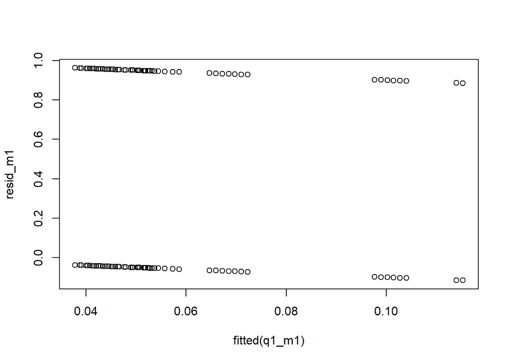

```r
plot(fitted(q1_m1), resid_m1)
```

Question 1, Model 1 Analysis: Although we observe statistically significant results for our variables (albeit at varying levels of significance), this model does not help us fully identify how COVID has impacted the retail industry. Our residual plotting chart shows that a LOGIT model may work better as we are using Unemployed (our binary dependent variable) as the ultimate variable of interest. Based on this analysis, we wanted to introduce an interaction term for question one in order to identify the impact of COVID after April 1, 2020, the date that we assume COVID would have the biggest impact on Unemployment which is shown in our next model.

### Question 1, Model 2:

```r
q1_m2 <- feols(Unemployed ~ YEAR*Covid_April + YEAR + MONTH + REGION + covid1_dummy + covid2_dummy + covid3_dummy,
               data = q1_df,
               weights = q1_df$WTFINL,
               vcov = 'hetero')
etable(q1_m2)
```

```
##                                              q1_m2
## Dependent Var.:                         Unemployed
##
## (Intercept)                       17.68*** (2.046)
## YEAR                           -0.0087*** (0.0010)
## Covid_April                       45.41*** (4.418)
## MONTH                          -0.0031*** (0.0002)
## REGIONEastSouthCentralDivision -0.0153*** (0.0022)
## REGIONMiddleAtlanticDivision    0.0129*** (0.0023)
## REGIONMountainDivision          -0.0062** (0.0021)
## REGIONNewEnglandDivision         -0.0053* (0.0023)
## REGIONPacificDivision            0.0051** (0.0020)
## REGIONSouthAtlanticDivision      -0.0037* (0.0018)
## REGIONWestNorthCentralDivision -0.0162*** (0.0021)
## REGIONWestSouthCentralDivision -0.0097*** (0.0020)
## covid1_dummy                    0.0396*** (0.0039)
## covid2_dummy                       0.0027 (0.0038)
## covid3_dummy                   -0.0135*** (0.0024)
## YEAR x Covid_April             -0.0224*** (0.0022)
## ______________________________ ___________________
## S.E. type                      Heteroskedast.-rob.
## Observations                               308,217
## R2                                         0.01133
## Adj. R2                                    0.01128
## ---
## Signif. codes: 0 '***' 0.001 '**' 0.01 '*' 0.05 '.' 0.1 ' ' 1
```

### Question 1, Model 3:

```r
q1_m3 <- feglm(Unemployed ~ YEAR*Covid_April + YEAR + MONTH |
                 REGION + covid1_dummy + covid2_dummy + covid3_dummy,
               data = q1_df,
               family = binomial(link = 'logit'))
etable(q1_m3)
```

```
##                                  q1_m3
## Dependent Var.:             Unemployed
##
## YEAR               -0.1333*** (0.0201)
## Covid_April           694.2*** (128.1)
## MONTH              -0.0524*** (0.0039)
## YEAR x Covid_April -0.3431*** (0.0634)
## Fixed-Effects:     -------------------
## REGION                             Yes
## covid1_dummy                       Yes
## covid2_dummy                       Yes
## covid3_dummy                       Yes
## __________________ ___________________
## S.E.: Clustered             by: REGION
## Observations                   308,217
## Squared Cor.                   0.01035
## Pseudo R2                      0.01935
## BIC                          124,875.3
## ---
## Signif. codes: 0 '***' 0.001 '**' 0.01 '*' 0.05 '.' 0.1 ' ' 1
```

```r
log_q1_m3 <- marginaleffects(q1_m3)
log_m3 <- summary(log_q1_m3)

kable(x = log_m3,
      format = "html",
      caption = "Low Marginal Effect of Retail or Not")
```

| type | term | estimate | std.error | statistic | p.value | conf.low | conf.high |
| --- | --- | --- | --- | --- | --- | --- | --- |
| response | YEAR | -0.0159397 | 0.5392946 | -0.0295566 | 0.9764207 | -1.0729377 | 1.0410583 |
| response | Covid_April | 0.0563282 | 1.7525595 | 0.0321405 | 0.9743600 | -3.3786253 | 3.4912817 |
| response | MONTH | -0.0025901 | 0.0926264 | -0.0279629 | 0.9776917 | -0.1841345 | 0.1789542 |

```r
# Using Predictions to gather probabilities of our scenarios:
summ_during_covid <- summary(predictions(q1_m3, newdata = datagrid(Covid_April = 1)))
kable(x = summ_during_covid,
      format = "html",
      caption = "During Covid Retail Unemployment")
```

During Covid Retail Unemployment

| estimate | std.error | statistic | p.value | conf.low | conf.high |
| --- | --- | --- | --- | --- | --- |
| 0.1129042 | 3.796795 | 0.0297367 | 0.976277 | -7.328678 | 7.554487 |

```r
summ_before_covid <- summary(predictions(q1_m3, newdata = datagrid(Covid_April = 0)))
kable(x = summ_before_covid,
      format = "html",
      caption = "Before Covid Retail Unemployment")
```

Before Covid Retail Unemployment

| estimate | std.error | statistic | p.value | conf.low | conf.high |
| --- | --- | --- | --- | --- | --- |
| 0.0378384 | 1.624496 | 0.0232924 | 0.981417 | -3.146116 | 3.221793 |

Q1 Model 3 Logit Plot

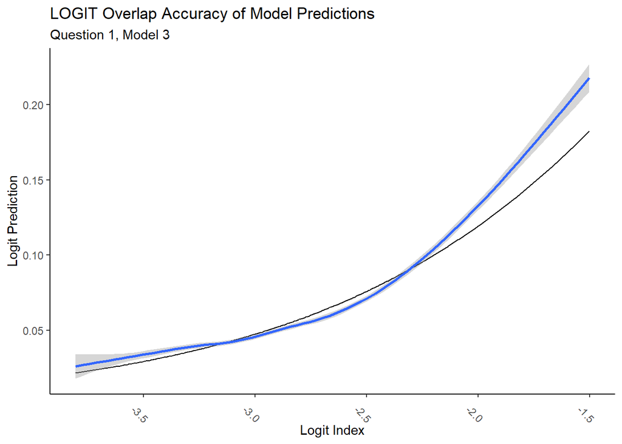

```r
# mutate original q1 dataframe to include prediciton and index
q1_df <- q1_df %>%
  mutate(logit_predict = predict(q1_m3,
                                 type = 'response',
                                 newdata = q1_df)) %>%
  mutate(logit_index = predict(q1_m3,
                               type = 'link',
                               newdata = q1_df))

q1_logit_plot <- q1_df %>%
  ggplot() +
  geom_line(aes(x = logit_index,
                y = logit_predict)) +
  geom_smooth(aes(x = logit_index,
                  y = Unemployed)) +
  labs(x = 'Logit Index',
       y = 'Logit Prediction',
       title = 'LOGIT Overlap Accuracy of Model Predictions',
       subtitle = 'Question 1, Model 3') +
  theme(axis.text.x = element_text(angle = -45),
        panel.grid.major = element_blank(),
        panel.grid.minor = element_blank(),
        panel.background = element_blank(),
        axis.line = element_line(color = ))

q1_logit_plot
```

## 2 How has retail fared relative to other industries?

-Jordan:

```r
ques2 <- clean_df %>% dplyr::select(YEAR, MONTH, monthyear, CPSID, WTFINL, AGE, SEX, RACE, CLASSWKR, WHYUNEMP, WKSTAT, INDNAME, covid1_dummy, covid2_dummy, covid3_dummy, REGION)

#Should I control for region and for covid dummies?

ques2$employed_full <- ifelse(ques2$WKSTAT %in% c("Full-time hours (35+), usually full-time", "Full-time hours (35+), usually part-time for economic reasons", "Full-time hours (35+), usually part-time for non-economic reasons"), 1, 0)


ques2$job_loser <- ifelse(ques2$WHYUNEMP %in% c("Job loser - on layoff", "Other job loser"), 1, 0)

ques2$retail_or_not <- ifelse(ques2$INDNAME %in% c("Retail Trade"), 1, 0)
```

This first regression looks at how full time employment has faired over the span of time for the covid waves, and has controls for the different waves of covid, as well as region and implements the weights argument.

```r
#mod1
ques2m1 <- feols(employed_full ~ INDNAME + YEAR + MONTH + REGION + covid1_dummy + covid2_dummy + covid3_dummy, data= ques2,
                 weights = ques2$WTFINL)
```

```
## NOTE: 20,666 observations removed because of 0-weight.
```

```r
etable(ques2m1)
```

```
##                                                                                                      ques2m1
## Dependent Var.:                                                                                employed_full
##
## (Intercept)                                                                                1.832*** (0.3065)
## INDNAMEArts,Entertainment,andRecreation,andAccommodationandFoodServices                  -0.2387*** (0.0017)
## INDNAMEConstruction                                                                       0.0256*** (0.0018)
## INDNAMEEducationalServices,andHealthCareandSocialAssistance                              -0.0388*** (0.0016)
## INDNAMEFinanceandInsurance,andRealEstateandRentalandLeasing                               0.0769*** (0.0018)
## INDNAMEInformation                                                                        0.0227*** (0.0023)
## INDNAMEManufacturing                                                                      0.1069*** (0.0017)
## INDNAMEMilitary                                                                          -0.7189*** (0.0190)
## INDNAMENotretail                                                                         -0.7200*** (0.0016)
## INDNAMEOtherServices,ExceptPublicAdministration                                          -0.1038*** (0.0019)
## INDNAMEProfessional,Scientific,andManagement,andAdministrativeandWasteManagementServices  0.0176*** (0.0017)
## INDNAMEPublicAdministration                                                               0.0927*** (0.0019)
## INDNAMERetailTrade                                                                       -0.1069*** (0.0017)
## INDNAMETransportationandWarehousing,andUtilities                                          0.0229*** (0.0018)
## INDNAMEWholesaleTrade                                                                     0.0944*** (0.0022)
## YEAR                                                                                     -0.0006*** (0.0002)
## MONTH                                                                                    0.0003*** (5.53e-5)
## REGIONEastSouthCentralDivision                                                            0.0340*** (0.0009)
## REGIONMiddleAtlanticDivision                                                              0.0163*** (0.0007)
## REGIONMountainDivision                                                                    0.0069*** (0.0008)
## REGIONNewEnglandDivision                                                                   -0.0024* (0.0010)
## REGIONPacificDivision                                                                     0.0065*** (0.0007)
## REGIONSouthAtlanticDivision                                                               0.0397*** (0.0006)
## REGIONWestNorthCentralDivision                                                            0.0103*** (0.0009)
## REGIONWestSouthCentralDivision                                                            0.0313*** (0.0007)
## covid1_dummy                                                                             -0.0540*** (0.0010)
## covid2_dummy                                                                             -0.0573*** (0.0006)
## covid3_dummy                                                                             -0.0141*** (0.0005)
## ________________________________________                                                 ___________________
## S.E. type                                                                                                IID
## Observations                                                                                       4,176,227
## R2                                                                                                   0.43746
## Adj. R2                                                                                              0.43745
## ---
## Signif. codes: 0 '***' 0.001 '**' 0.01 '*' 0.05 '.' 0.1 ' ' 1
```

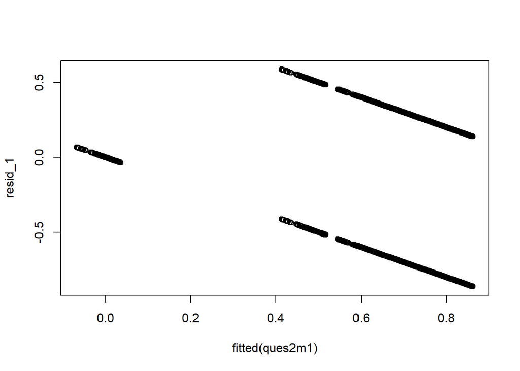

```r
resid_1 <- resid(ques2m1)
plot(fitted(ques2m1), resid_1)
```

## WALD tests Question 2

```r
wald(ques2m1, c("YEAR", "MONTH")) #both are useful
```

```
## Wald test, H0: joint nullity of YEAR and MONTH
##  stat = 24.3, p-value = 2.796e-11, on 2 and 4,176,199 DoF, VCOV: IID.
```

```r
wald(ques2m1, c("REGION")) # All regions are significant
```

```
## Wald test, H0: joint nullity of REGIONEast South Central Division, REGIONMiddle Atlantic Division, REGIONMountain Division, REGIONNew England Division, REGIONPacific Division, REGIONSouth Atlantic Division and 2 others
##  stat = 858.1, p-value < 2.2e-16, on 8 and 4,176,199 DoF, VCOV: IID.
```

```r
wald(ques2m1, c( "covid1_dummy", "covid2_dummy", "covid3_dummy")) # all are significant and useful
```

```
## Wald test, H0: joint nullity of covid1_dummy, covid2_dummy and covid3_dummy
##  stat = 3,754.7, p-value < 2.2e-16, on 3 and 4,176,199 DoF, VCOV: IID.
```

Certainly seems like a binary variable logit model would be more appropriate. I want to verify how job loss looks compared to job maintained first before checking that. The variable Job loser helps look at if the respondent was layed off or lost their job in any way over the span of time.

```r
#mod2
ques2m2 <- feols(job_loser ~ retail_or_not + INDNAME + YEAR + MONTH | REGION + covid1_dummy + covid2_dummy + covid3_dummy,
                 data = ques2, weights = ques2$WTFINL, vcov='hetero')
```

```
## NOTE: 20,666 observations removed because of 0-weight.
```

```
## The variable 'INDNAMERetail Trade' has been removed because of collinearity (see $collin.var).
```

```r
etable(ques2m2)
```

```
##                                                                                                      ques2m2
## Dependent Var.:                                                                                    job_loser
##
## retail_or_not                                                                            -0.0086*** (0.0010)
## INDNAMEArts,Entertainment,andRecreation,andAccommodationandFoodServices                   0.0146*** (0.0010)
## INDNAMEConstruction                                                                          0.0009 (0.0010)
## INDNAMEEducationalServices,andHealthCareandSocialAssistance                              -0.0182*** (0.0009)
## INDNAMEFinanceandInsurance,andRealEstateandRentalandLeasing                              -0.0214*** (0.0010)
## INDNAMEInformation                                                                       -0.0102*** (0.0012)
## INDNAMEManufacturing                                                                     -0.0115*** (0.0010)
## INDNAMEMilitary                                                                            0.0459** (0.0177)
## INDNAMENotretail                                                                         -0.0366*** (0.0009)
## INDNAMEOtherServices,ExceptPublicAdministration                                          -0.0075*** (0.0010)
## INDNAMEProfessional,Scientific,andManagement,andAdministrativeandWasteManagementServices -0.0120*** (0.0010)
## INDNAMEPublicAdministration                                                              -0.0284*** (0.0009)
## INDNAMETransportationandWarehousing,andUtilities                                         -0.0081*** (0.0010)
## INDNAMEWholesaleTrade                                                                    -0.0134*** (0.0011)
## YEAR                                                                                     0.0002*** (4.97e-5)
## MONTH                                                                                    -0.0004*** (2.1e-5)
## Fixed-Effects:                                                                           -------------------
## REGION                                                                                                   Yes
## covid1_dummy                                                                                             Yes
## covid2_dummy                                                                                             Yes
## covid3_dummy                                                                                             Yes
## ________________________________________                                                 ___________________
## S.E. type                                                                                Heteroskedast.-rob.
## Observations                                                                                       4,176,227
## R2                                                                                                   0.02334
## Within R2                                                                                            0.01247
## ---
## Signif. codes: 0 '***' 0.001 '**' 0.01 '*' 0.05 '.' 0.1 ' ' 1
```

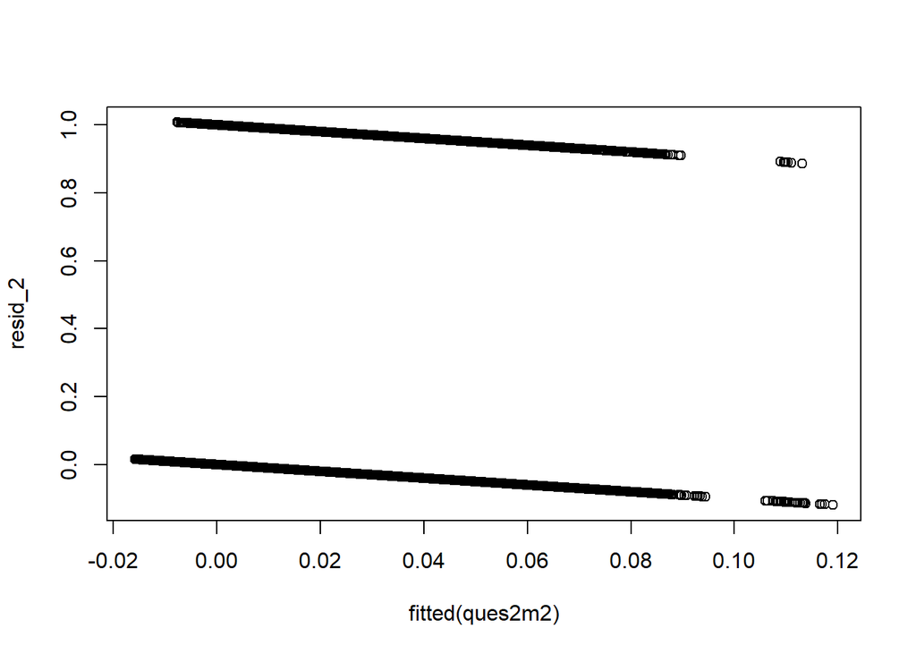

```r
resid_2 <- resid(ques2m2)
plot(fitted(ques2m2), resid_2)
```

```r
wald(ques2m2, c("YEAR", "MONTH")) #both are useful
```

```
## Wald test, H0: joint nullity of YEAR and MONTH
##  stat = 161.1, p-value < 2.2e-16, on 2 and 4,176,199 DoF, VCOV: Heteroskedasticity-robust.
```

```r
wald(ques2m2, c("REGION")) # All regions are significant
```

```
## [1] NA
```

```r
wald(ques2m2, c("covid1_dummy", "covid2_dummy", "covid3_dummy")) # all are significant and useful
```

```
## [1] NA
```

There is a very minor difference between loss of job and those that became unemployed, so we observe that in this regression:

```r
#mod3
ques2$unemper <- ifelse(ques2$WKSTAT %in% c("Unemployed, seeking part-time work", "Unemployed, seeking full-time work"), 1, 0)

avg_unemper <- mean(ques2$unemper) #looking for what the probability of being generally unemployed is

ques2m3 <- feols(unemper ~ retail_or_not + YEAR + MONTH | REGION + covid1_dummy + covid2_dummy + covid3_dummy,
                 data = ques2, weights = ques2$WTFINL, vcov='hetero')
```

```
## NOTE: 20,666 observations removed because of 0-weight.
```

```r
etable(ques2m3)
```

```
##                              ques2m3
## Dependent Var.:              unemper
##
## retail_or_not     0.0245*** (0.0005)
## YEAR                  7.38e-5 (8e-5)
## MONTH           -0.0004*** (3.07e-5)
## Fixed-Effects:  --------------------
## REGION                           Yes
## covid1_dummy                     Yes
## covid2_dummy                     Yes
## covid3_dummy                     Yes
## _______________ ____________________
## S.E. type       Heteroskedasti.-rob.
## Observations               4,176,227
## R2                           0.00724
## Within R2                    0.00127
## ---
## Signif. codes: 0 '***' 0.001 '**' 0.01 '*' 0.05 '.' 0.1 ' ' 1
```

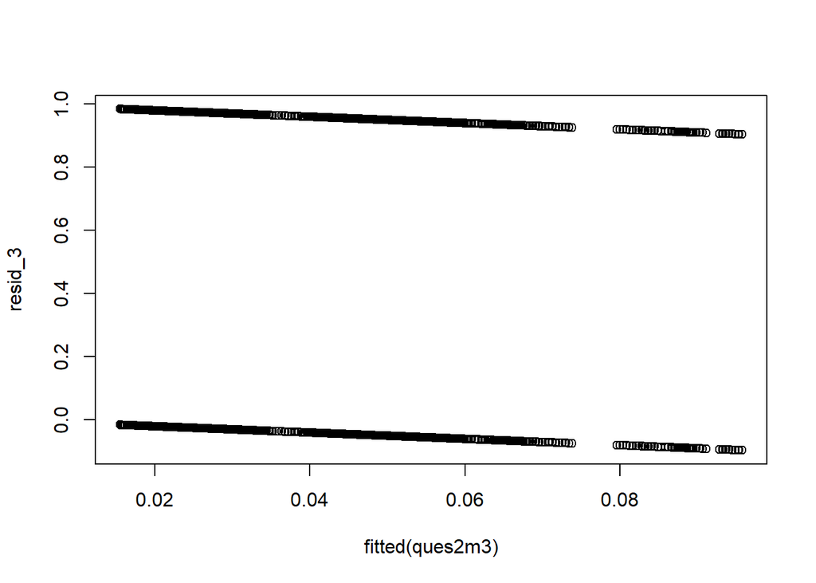

```r
resid_3 <- resid(ques2m3)
plot(fitted(ques2m3), resid_3)
```

```r
wald(ques2m3, c("YEAR", "MONTH")) #both are useful
```

```
## Wald test, H0: joint nullity of YEAR and MONTH
##  stat = 97.1, p-value < 2.2e-16, on 2 and 4,176,212 DoF, VCOV: Heteroskedasticity-robust.
```

```r
wald(ques2m3, c("REGION")) # All regions are significant
```

```
## [1] NA
```

```r
wald(ques2m3, c("covid1_dummy", "covid2_dummy", "covid3_dummy")) # all are significant and useful
```

```
## [1] NA
```

## Comparing Through Etable

```r
etable(ques2m1, ques2m2, ques2m3)
```

```
##                                                                                                      ques2m1
## Dependent Var.:                                                                                employed_full
##
## (Intercept)                                                                                1.832*** (0.3065)
## INDNAMEArts,Entertainment,andRecreation,andAccommodationandFoodServices                  -0.2387*** (0.0017)
## INDNAMEConstruction                                                                       0.0256*** (0.0018)
## INDNAMEEducationalServices,andHealthCareandSocialAssistance                              -0.0388*** (0.0016)
## INDNAMEFinanceandInsurance,andRealEstateandRentalandLeasing                               0.0769*** (0.0018)
## INDNAMEInformation                                                                        0.0227*** (0.0023)
## INDNAMEManufacturing                                                                      0.1069*** (0.0017)
## INDNAMEMilitary                                                                          -0.7189*** (0.0190)
## INDNAMENotretail                                                                         -0.7200*** (0.0016)
## INDNAMEOtherServices,ExceptPublicAdministration                                          -0.1038*** (0.0019)
## INDNAMEProfessional,Scientific,andManagement,andAdministrativeandWasteManagementServices  0.0176*** (0.0017)
## INDNAMEPublicAdministration                                                               0.0927*** (0.0019)
## INDNAMERetailTrade                                                                       -0.1069*** (0.0017)
## INDNAMETransportationandWarehousing,andUtilities                                          0.0229*** (0.0018)
## INDNAMEWholesaleTrade                                                                     0.0944*** (0.0022)
## YEAR                                                                                     -0.0006*** (0.0002)
## MONTH                                                                                    0.0003*** (5.53e-5)
## REGIONEastSouthCentralDivision                                                            0.0340*** (0.0009)
## REGIONMiddleAtlanticDivision                                                              0.0163*** (0.0007)
## REGIONMountainDivision                                                                    0.0069*** (0.0008)
## REGIONNewEnglandDivision                                                                   -0.0024* (0.0010)
## REGIONPacificDivision                                                                     0.0065*** (0.0007)
## REGIONSouthAtlanticDivision                                                               0.0397*** (0.0006)
## REGIONWestNorthCentralDivision                                                            0.0103*** (0.0009)
## REGIONWestSouthCentralDivision                                                            0.0313*** (0.0007)
## covid1_dummy                                                                             -0.0540*** (0.0010)
## covid2_dummy                                                                             -0.0573*** (0.0006)
## covid3_dummy                                                                             -0.0141*** (0.0005)
## retail_or_not
## Fixed-Effects:                                                                           -------------------
## REGION                                                                                                    No
## covid1_dummy                                                                                              No
## covid2_dummy                                                                                              No
## covid3_dummy                                                                                              No
## ________________________________________                                                 ___________________
## S.E. type                                                                                                IID
## Observations                                                                                       4,176,227
```

[output cut: 75 more lines]

```
## covid2_dummy
## covid3_dummy
## retail_or_not                                                                              0.0245*** (0.0005)
## Fixed-Effects:                                                                           --------------------
## REGION                                                                                                    Yes
## covid1_dummy                                                                                              Yes
## covid2_dummy                                                                                              Yes
## covid3_dummy                                                                                              Yes
## ________________________________________                                                 ____________________
## S.E. type                                                                                Heteroskedasti.-rob.
## Observations                                                                                        4,176,227
## R2                                                                                                    0.00724
## Within R2                                                                                             0.00127
## ---
## Signif. codes: 0 '***' 0.001 '**' 0.01 '*' 0.05 '.' 0.1 ' ' 1
```

### Now a Logit response for question 2, which will more directly answer the question we are looking at: How did retail do as far as loss of jobs over time, compared with other industries

```r
ques2logit <- feglm(unemper ~ retail_or_not + YEAR + MONTH | REGION + covid1_dummy + covid2_dummy + covid3_dummy,
                 data = ques2, weights = ques2$WTFINL, family = binomial(link = 'logit')) # iremoved the weights
```

```
## NOTE: 20,666 observations removed because of 0-weight.
```

```r
log_m <- marginaleffects(ques2logit)
summary(log_m)
```

```
##            Term     Effect Std. Error  z value Pr(>|z|)    2.5 %   97.5 %
## 1 retail_or_not  1.907e-02   0.349577  0.05455  0.95650 -0.66609 0.704227
## 2          YEAR  7.786e-05   0.001790  0.04351  0.96530 -0.00343 0.003585
## 3         MONTH -4.550e-04   0.008312 -0.05474  0.95635 -0.01675 0.015836
##
## Model type:  fixest
## Prediction type:  response
```

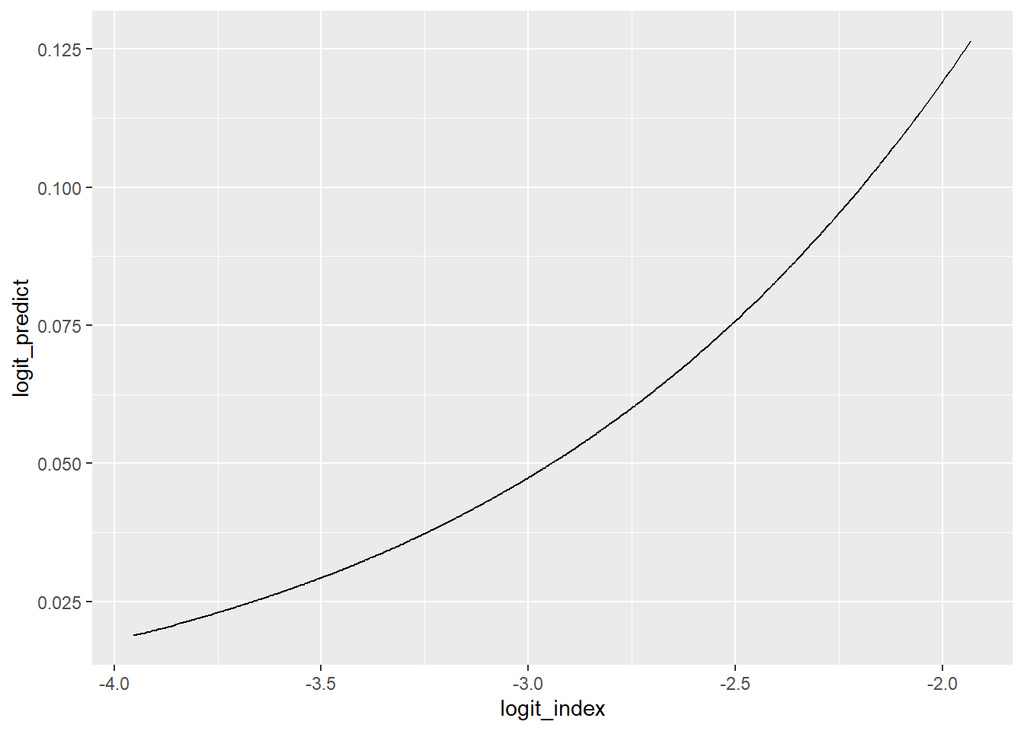

```r
ques2 <- ques2 %>% mutate(logit_predict = predict(ques2logit, type="response", newdata=ques2))
ques2 <- ques2 %>% mutate(logit_index = predict(ques2logit, type="link", newdata=ques2))




ques2 %>% ggplot() +
  geom_line(aes(x=logit_index, y=logit_predict))
```

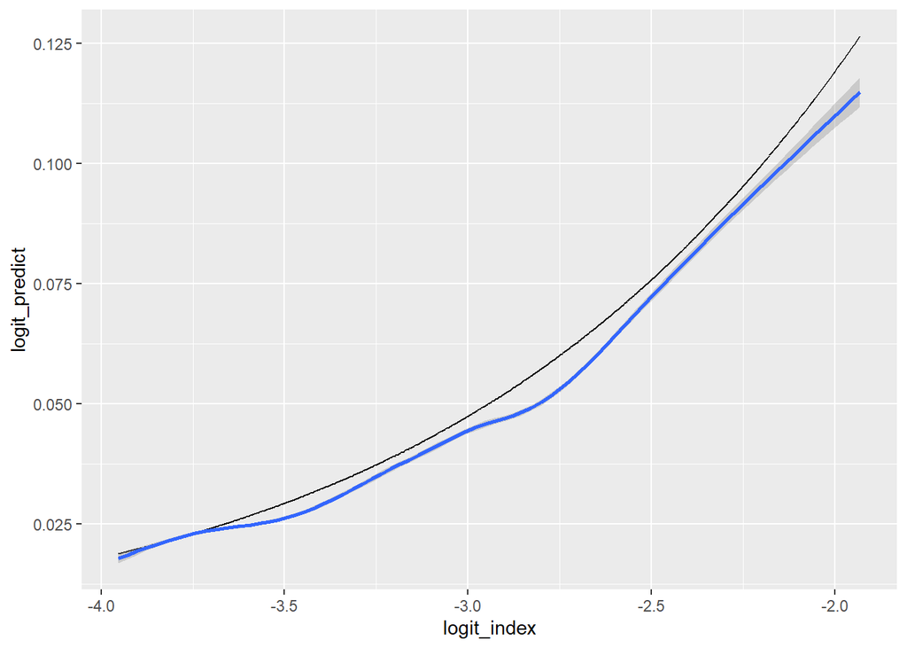

```r
ques2 %>% ggplot() +
  geom_line(aes(x=logit_index, y=logit_predict)) + geom_smooth(aes(x=logit_index, y=unemper))
```

# This shows that the lines are overlapping a good amount, meaning that our predictions are accurate. #Now an attempt at making an interaction term:

```r
# Creating a dummy variable to see before and during covid. I will keep the assumption that March was the first wave of covid, but
#the layoffs would have initiated after covid had lingered, so I am marking in April:

ques2$covid_april <- ifelse(ques2$monthyear >= '2020-04-01', 1, 0) # the 1 is layoffs in #april

ques2logit2 <- feglm(unemper ~ retail_or_not*covid_april + YEAR + MONTH | REGION + covid1_dummy + covid2_dummy + covid3_dummy,
                 data = ques2, weights = ques2$WTFINL, family = binomial(link = 'logit')) # iremoved the weights
```

```
## NOTE: 20,666 observations removed because of 0-weight.
```

```r
log_m2 <- marginaleffects(ques2logit2)
summary(log_m2)
```

```
##            Term    Effect Std. Error  z value Pr(>|z|)    2.5 %  97.5 %
## 1 retail_or_not  0.019048    0.24896  0.07651  0.93901 -0.46891 0.50701
## 2   covid_april  0.026030    0.34027  0.07650  0.93902 -0.64089 0.69295
## 3          YEAR -0.007393    0.09653 -0.07658  0.93896 -0.19659 0.18181
## 4         MONTH -0.001040    0.01358 -0.07658  0.93895 -0.02766 0.02558
##
## Model type:  fixest
## Prediction type:  response
```

```r
etable(ques2logit2)
```

```
##                                     ques2logit2
## Dependent Var.:                         unemper
##
## retail_or_not                0.5839*** (0.0369)
## covid_april                  0.7885*** (0.0324)
## YEAR                        -0.2235*** (0.0065)
## MONTH                       -0.0314*** (0.0014)
## retail_or_not x covid_april    -0.0139 (0.0330)
## Fixed-Effects:              -------------------
## REGION                                      Yes
## covid1_dummy                                Yes
## covid2_dummy                                Yes
## covid3_dummy                                Yes
## ___________________________ ___________________
## S.E.: Clustered                      by: REGION
## Observations                          4,176,227
## Squared Cor.                            0.00715
## Pseudo R2                               0.02301
## BIC                                         0.5
## ---
## Signif. codes: 0 '***' 0.001 '**' 0.01 '*' 0.05 '.' 0.1 ' ' 1
```

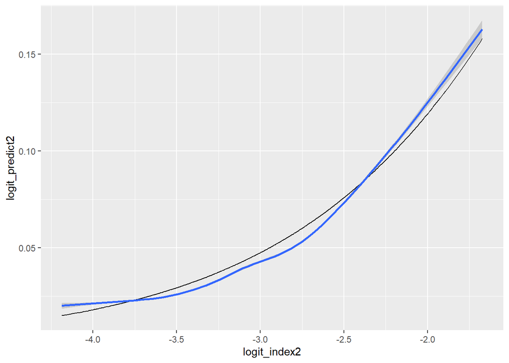

```r
ques2 <- ques2 %>% mutate(logit_predict2 = predict(ques2logit2, type="response", newdata=ques2))
ques2 <- ques2 %>% mutate(logit_index2 = predict(ques2logit2, type="link", newdata=ques2))



ques2 %>% ggplot() +
  geom_line(aes(x=logit_index2, y=logit_predict2)) + geom_smooth(aes(x=logit_index2, y=unemper))
```

# the interaction term enables interesting interpretation, but is a less accurate model.

## 3 Retail needs to worry about who has money to spend - what has changed about who is working and earning money?

-Brooke and Sean

Data for this Question:

```r
q3_df <- clean_df %>%
  mutate(sex_binary = ifelse(SEX =="Female", 1, 0)) %>%
  mutate(married = ifelse(MARST == "Married, spouse present", 1, 0)) %>%
  mutate(Employed = ifelse(WKSTAT %in% c("Full-time hours (35+), usually full-time",
                                         "Full-time hours (35+), usually part-time for economic reasons",
                                         "Full-time hours (35+), usually part-time for non-economic reasons"),
                           1, 0)) %>%
  mutate(all_covid = ifelse(monthyear >= '2020-03-01', 1, 0)) %>%
  dplyr::select(c(WKSTAT, Employed, IncNumber,YEAR, MONTH, race_dummy, student_dummy, AGE, sex_binary,
                  married, NCHILD,covid1_dummy, covid2_dummy, covid3_dummy, REGION, all_covid))
```

Who is Working: Dependent variable: Employed Explanatory variables: YEAR, MONTH, race_dummy, student_dummy, Age, sex (WORK ON THIS ONE), MARST (make dummy), NCHILD, COVID Dummies, REGION

Starting small and gradually getting bigger

```r
q3m1 <- feols(Employed ~ race_dummy + student_dummy + AGE + sex_binary + covid1_dummy + covid2_dummy + covid3_dummy,
              data=q3_df)
etable(q3m1)
```

```
##                                 q3m1
## Dependent Var.:             Employed
##
## (Intercept)       0.8476*** (0.0009)
## race_dummy        0.0242*** (0.0006)
## student_dummy    -0.5231*** (0.0009)
## AGE             -0.0056*** (1.65e-5)
## sex_binary       -0.1411*** (0.0005)
## covid1_dummy     -0.0508*** (0.0013)
## covid2_dummy     -0.0615*** (0.0008)
## covid3_dummy     -0.0198*** (0.0006)
## _______________ ____________________
## S.E. type                        IID
## Observations               4,196,893
## R2                           0.10402
## Adj. R2                      0.10402
## ---
## Signif. codes: 0 '***' 0.001 '**' 0.01 '*' 0.05 '.' 0.1 ' ' 1
```

```r
q3m2 <- feols(Employed ~ race_dummy + student_dummy + AGE + sex_binary + covid1_dummy + covid2_dummy +
                covid3_dummy + married + NCHILD + REGION,
              data=q3_df)
etable(q3m2)
```

```
##                                                q3m2
## Dependent Var.:                            Employed
##
## (Intercept)                      0.8173*** (0.0012)
## race_dummy                       0.0149*** (0.0006)
## student_dummy                   -0.4881*** (0.0009)
## AGE                            -0.0060*** (1.74e-5)
## sex_binary                      -0.1436*** (0.0005)
## covid1_dummy                    -0.0518*** (0.0013)
## covid2_dummy                    -0.0616*** (0.0008)
## covid3_dummy                    -0.0191*** (0.0006)
## married                          0.0720*** (0.0005)
## NCHILD                           0.0219*** (0.0002)
## REGIONEastSouthCentralDivision  -0.0113*** (0.0011)
## REGIONMiddleAtlanticDivision     0.0070*** (0.0011)
## REGIONMountainDivision          -0.0140*** (0.0010)
## REGIONNewEnglandDivision         0.0159*** (0.0011)
## REGIONPacificDivision           -0.0201*** (0.0009)
## REGIONSouthAtlanticDivision      0.0174*** (0.0009)
## REGIONWestNorthCentralDivision   0.0361*** (0.0010)
## REGIONWestSouthCentralDivision    -0.0020* (0.0010)
## ______________________________ ____________________
## S.E. type                                       IID
## Observations                              4,196,893
## R2                                          0.11404
## Adj. R2                                     0.11404
## ---
## Signif. codes: 0 '***' 0.001 '**' 0.01 '*' 0.05 '.' 0.1 ' ' 1
```

```r
q3m3 <- feols(Employed ~ race_dummy + student_dummy + AGE + sex_binary + all_covid,
              data=q3_df)
etable(q3m3)
```

```
##                                 q3m3
## Dependent Var.:             Employed
##
## (Intercept)       0.8499*** (0.0010)
## race_dummy        0.0239*** (0.0006)
## student_dummy    -0.5229*** (0.0009)
## AGE             -0.0056*** (1.66e-5)
## sex_binary       -0.1411*** (0.0005)
## all_covid        -0.0272*** (0.0005)
## _______________ ____________________
## S.E. type                        IID
## Observations               4,196,893
## R2                           0.10314
## Adj. R2                      0.10313
## ---
## Signif. codes: 0 '***' 0.001 '**' 0.01 '*' 0.05 '.' 0.1 ' ' 1
```

```r
q3m4 <- feols(Employed ~ all_covid + AGE + race_dummy + sex_binary +
                I(all_covid*AGE) + I(all_covid*race_dummy) + I(all_covid*sex_binary),
              data=q3_df)
etable(q3m4)
```

```
##                                           q3m4
## Dependent Var.:                       Employed
##
## (Intercept)                 0.5963*** (0.0012)
## all_covid                  -0.0301*** (0.0017)
## AGE                       -0.0009*** (2.13e-5)
## race_dummy                  0.0275*** (0.0008)
## sex_binary                 -0.1527*** (0.0007)
## I(all_covid x AGE)        -9.79e-5** (3.07e-5)
## I(all_covid x race_dummy)    0.0039** (0.0012)
## I(all_covid x sex_binary)   0.0110*** (0.0010)
## _________________________ ____________________
## S.E. type                                  IID
## Observations                         4,196,893
## R2                                     0.02417
## Adj. R2                                0.02417
## ---
## Signif. codes: 0 '***' 0.001 '**' 0.01 '*' 0.05 '.' 0.1 ' ' 1
```

Starting small and gradually getting bigger

```r
q3m5 <- feols(Employed ~ race_dummy + student_dummy + AGE + sex_binary + covid1_dummy + covid2_dummy + covid3_dummy,
              data=q3_df)
etable(q3m5)
```

```
##                                 q3m5
## Dependent Var.:             Employed
##
## (Intercept)       0.8476*** (0.0009)
## race_dummy        0.0242*** (0.0006)
## student_dummy    -0.5231*** (0.0009)
## AGE             -0.0056*** (1.65e-5)
## sex_binary       -0.1411*** (0.0005)
## covid1_dummy     -0.0508*** (0.0013)
## covid2_dummy     -0.0615*** (0.0008)
## covid3_dummy     -0.0198*** (0.0006)
## _______________ ____________________
## S.E. type                        IID
## Observations               4,196,893
## R2                           0.10402
## Adj. R2                      0.10402
## ---
## Signif. codes: 0 '***' 0.001 '**' 0.01 '*' 0.05 '.' 0.1 ' ' 1
```

```r
q3m6 <- feols(Employed ~ race_dummy + student_dummy + AGE + sex_binary + covid1_dummy + covid2_dummy +
                covid3_dummy + married + NCHILD + REGION,
              data=q3_df)
etable(q3m6)
```

```
##                                                q3m6
## Dependent Var.:                            Employed
##
## (Intercept)                      0.8173*** (0.0012)
## race_dummy                       0.0149*** (0.0006)
## student_dummy                   -0.4881*** (0.0009)
## AGE                            -0.0060*** (1.74e-5)
## sex_binary                      -0.1436*** (0.0005)
## covid1_dummy                    -0.0518*** (0.0013)
## covid2_dummy                    -0.0616*** (0.0008)
## covid3_dummy                    -0.0191*** (0.0006)
## married                          0.0720*** (0.0005)
## NCHILD                           0.0219*** (0.0002)
## REGIONEastSouthCentralDivision  -0.0113*** (0.0011)
## REGIONMiddleAtlanticDivision     0.0070*** (0.0011)
## REGIONMountainDivision          -0.0140*** (0.0010)
## REGIONNewEnglandDivision         0.0159*** (0.0011)
## REGIONPacificDivision           -0.0201*** (0.0009)
## REGIONSouthAtlanticDivision      0.0174*** (0.0009)
## REGIONWestNorthCentralDivision   0.0361*** (0.0010)
## REGIONWestSouthCentralDivision    -0.0020* (0.0010)
## ______________________________ ____________________
## S.E. type                                       IID
## Observations                              4,196,893
## R2                                          0.11404
## Adj. R2                                     0.11404
## ---
## Signif. codes: 0 '***' 0.001 '**' 0.01 '*' 0.05 '.' 0.1 ' ' 1
```

```r
q3m7 <- feols(Employed ~ race_dummy + student_dummy + AGE + sex_binary + all_covid,
              data=q3_df)
etable(q3m7)
```

```
##                                 q3m7
## Dependent Var.:             Employed
##
## (Intercept)       0.8499*** (0.0010)
## race_dummy        0.0239*** (0.0006)
## student_dummy    -0.5229*** (0.0009)
## AGE             -0.0056*** (1.66e-5)
## sex_binary       -0.1411*** (0.0005)
## all_covid        -0.0272*** (0.0005)
## _______________ ____________________
## S.E. type                        IID
## Observations               4,196,893
## R2                           0.10314
## Adj. R2                      0.10313
## ---
## Signif. codes: 0 '***' 0.001 '**' 0.01 '*' 0.05 '.' 0.1 ' ' 1
```

```r
q3m8 <- feols(Employed ~ all_covid + AGE + race_dummy + sex_binary +
                I(all_covid*AGE) + I(all_covid*race_dummy) + I(all_covid*sex_binary),
              data=q3_df)
etable(q3m8)
```

```
##                                           q3m8
## Dependent Var.:                       Employed
##
## (Intercept)                 0.5963*** (0.0012)
## all_covid                  -0.0301*** (0.0017)
## AGE                       -0.0009*** (2.13e-5)
## race_dummy                  0.0275*** (0.0008)
## sex_binary                 -0.1527*** (0.0007)
## I(all_covid x AGE)        -9.79e-5** (3.07e-5)
## I(all_covid x race_dummy)    0.0039** (0.0012)
## I(all_covid x sex_binary)   0.0110*** (0.0010)
## _________________________ ____________________
## S.E. type                                  IID
## Observations                         4,196,893
## R2                                     0.02417
## Adj. R2                                0.02417
## ---
## Signif. codes: 0 '***' 0.001 '**' 0.01 '*' 0.05 '.' 0.1 ' ' 1
```

```r
sean_df_q3 <- clean_df %>%
  mutate(Working = ifelse(clean_df$WKSTAT %in% c("Full-time hours (35+), usually full-time", "Full-time hours (35+), usually part-time for economic reasons", "Full-time hours (35+), usually part-time for non-economic reasons"), 1, 0) )


sean_df_q3$race_dummy <- as.factor(sean_df_q3$race_dummy)
sean_df_q3$student_dummy <- as.factor(sean_df_q3$student_dummy)



sean_df_q3$MARST %>% unique()
```

```
## [1] "Married, spouse present" "Divorced"
## [3] "Never married/single"    "Married, spouse absent"
## [5] "Separated"               "Widowed"
```

```r
#Tried turning employment into a binary variable and running a logit regression. I run into memory issues with the marginal effects so this won't work

# ques3m1 <- feglm(Working ~ CLASSWKR | covid1_dummy + covid2_dummy + covid3_dummy  , data = sean_df_q3, weights = sean_df_q3$WTFINL, family = 'logit')
#
# etable(ques3m1, se = 'hetero')
#
# wald(ques3m1)
#
# q3m1_me <- marginaleffects(ques3m1)
# summary(q3m1_me)
#
# q3m1_pred <- sean_df_q3 %>%
#   mutate(logit_predict = predict(log1), logit_index = predict(log1, type = 'link'))
```

```r
ques3m2 <- feols(IncNumber ~ AGE + race_dummy + student_dummy + MARST + YEAR |REGION + covid1_dummy + covid2_dummy + covid3_dummy  , data = sean_df_q3, weights = sean_df_q3$WTFINL, vcov = 'hetero')
```

```
## NOTES: 20,666 observations removed because of 0-weight.
##        82,421 observations removed because of NA values (LHS: 82,421).
```

```r
etable(ques3m2)
```

```
##                                         ques3m2
## Dependent Var.:                       IncNumber
##
## AGE                           -241.4*** (2.069)
## race_dummy1                  6,400.5*** (64.34)
## student_dummy1               7,403.4*** (98.81)
## MARSTMarried,spouseabsent    2,932.7*** (227.3)
## MARSTMarried,spousepresent  27,198.9*** (82.18)
## MARSTNevermarried/single     1,924.0*** (96.18)
## MARSTSeparated             -10,526.8*** (181.6)
## MARSTWidowed                -5,874.4*** (157.9)
## YEAR                         1,851.7*** (20.82)
## Fixed-Effects:             --------------------
## REGION                                      Yes
## covid1_dummy                                Yes
## covid2_dummy                                Yes
## covid3_dummy                                Yes
## __________________________ ____________________
## S.E. type                  Heteroskedasti.-rob.
## Observations                          4,094,063
## R2                                      0.09416
## Within R2                               0.08225
## ---
## Signif. codes: 0 '***' 0.001 '**' 0.01 '*' 0.05 '.' 0.1 ' ' 1
```

```r
wald(ques3m2,"AGE")
```

```
## Wald test, H0: nullity of AGE
##  stat = 13,611.5, p-value < 2.2e-16, on 1 and 4,094,042 DoF, VCOV: Heteroskedasticity-robust.
```

```r
wald(ques3m2,"race_dummy")
```

```
## Wald test, H0: nullity of race_dummy1
##  stat = 9,896.3, p-value < 2.2e-16, on 1 and 4,094,042 DoF, VCOV: Heteroskedasticity-robust.
```

```r
wald(ques3m2,"student_dummy")
```

```
## Wald test, H0: nullity of student_dummy1
##  stat = 5,614.4, p-value < 2.2e-16, on 1 and 4,094,042 DoF, VCOV: Heteroskedasticity-robust.
```

```r
wald(ques3m2,"MARST")
```

```
## Wald test, H0: joint nullity of MARSTMarried, spouse absent, MARSTMarried, spouse present, MARSTNever married/single, MARSTSeparated and MARSTWidowed
##  stat = 53,271.6, p-value < 2.2e-16, on 5 and 4,094,042 DoF, VCOV: Heteroskedasticity-robust.
```

```r
wald(ques3m2,"YEAR")
```

```
## Wald test, H0: nullity of YEAR
##  stat = 7,910.5, p-value < 2.2e-16, on 1 and 4,094,042 DoF, VCOV: Heteroskedasticity-robust.
```

Odd that Age is slightly negative so lets take a look

```r
table(sean_df_q3$AGE, sean_df_q3$IncNumber)
```

```
##
##       6500  8500 11500 13750 17500 22500 27500 32500 37500 45000 55000 67500
##   16   730   697  1290  1193  2069  2905  2911  3661  3641  5219  5807  7929
##   17   706   705  1277  1298  1986  2754  2976  3529  3416  5230  5779  8133
##   18   736   890  1097  1152  1959  2553  2694  3475  3571  4975  5538  7306
##   19  1019   999  1329  1141  2244  2647  2721  3273  3355  4631  4912  6621
##   20  1124  1101  1502  1226  2184  2985  2989  3440  3439  4871  5206  5902
##   21  1162  1109  1694  1402  2394  3379  3144  3812  3724  5168  5207  6456
##   22  1279  1162  1470  1373  2260  3468  3226  4118  3816  5362  5291  6291
##   23  1031   914  1398  1293  2138  3322  3264  3995  3765  5735  5900  6941
##   24   956   876  1202  1215  1931  3099  3304  4174  3983  5988  6099  7809
##   25   856   871  1308  1020  1983  3045  3355  4035  3978  6547  6481  8746
##   26   762   802  1227  1023  1935  3031  3165  4175  4120  6446  6910  9132
##   27   822   784  1082  1011  1882  2937  3269  4221  3875  6418  7179  9179
##   28   836   891  1256  1028  1820  2836  3207  4124  3969  6360  7049  9181
```

[output cut: 99 more lines]

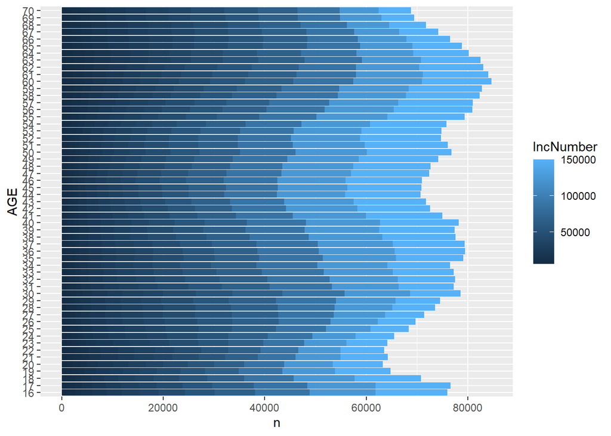

```r
plot <- sean_df_q3 %>%
  mutate(AGE = factor(AGE)) %>%
  count(AGE, IncNumber) %>%
  na.omit()

ggplot(plot, aes(x = AGE, y = n, fill = IncNumber)) +
  geom_col() +
  coord_flip()
```

```r
ques3m2.5 <- feols(IncNumber ~ AGE + I(AGE^2) | REGION + covid1_dummy + covid2_dummy + covid3_dummy  , data = sean_df_q3, weights = sean_df_q3$WTFINL, vcov = 'hetero')
```

```
## NOTES: 20,666 observations removed because of 0-weight.
##        82,421 observations removed because of NA values (LHS: 82,421).
```

```r
etable(ques3m2.5)
```

```
##                          ques3m2.5
## Dependent Var.:          IncNumber
##
## AGE             1,732.4*** (10.36)
## AGE square      -20.57*** (0.1178)
## Fixed-Effects:  ------------------
## REGION                         Yes
## covid1_dummy                   Yes
## covid2_dummy                   Yes
## covid3_dummy                   Yes
## _______________ __________________
## S.E. type       Heteroskedas.-rob.
## Observations             4,094,063
## R2                         0.02250
## Within R2                  0.00965
## ---
## Signif. codes: 0 '***' 0.001 '**' 0.01 '*' 0.05 '.' 0.1 ' ' 1
```

```r
wald(ques3m2.5)
```

```
## Wald test, H0: joint nullity of AGE and I(AGE^2)
##  stat = 15,802.3, p-value < 2.2e-16, on 2 and 4,094,049 DoF, VCOV: Heteroskedasticity-robust.
```

```r
wald(ques3m2.5, "AGE")
```

```
## Wald test, H0: joint nullity of AGE and I(AGE^2)
##  stat = 15,802.3, p-value < 2.2e-16, on 2 and 4,094,049 DoF, VCOV: Heteroskedasticity-robust.
```

```r
ques3m3 <- feols(IncNumber ~ race_dummy + student_dummy + MARST + YEAR | REGION + covid1_dummy + covid2_dummy + covid3_dummy  , data = sean_df_q3, weights = sean_df_q3$WTFINL, vcov = 'hetero')
```

```
## NOTES: 20,666 observations removed because of 0-weight.
##        82,421 observations removed because of NA values (LHS: 82,421).
```

```r
etable(ques3m3)
```

```
##                                        ques3m3
## Dependent Var.:                      IncNumber
##
## race_dummy1                 6,333.9*** (64.49)
## student_dummy1             10,741.7*** (94.01)
## MARSTMarried,spouseabsent   4,660.1*** (227.0)
## MARSTMarried,spousepresent 28,142.3*** (82.14)
## MARSTNevermarried/single    6,392.8*** (89.24)
## MARSTSeparated             -8,981.8*** (181.4)
## MARSTWidowed               -7,602.4*** (157.7)
## YEAR                        1,822.8*** (20.85)
## Fixed-Effects:             -------------------
## REGION                                     Yes
## covid1_dummy                               Yes
## covid2_dummy                               Yes
## covid3_dummy                               Yes
## __________________________ ___________________
## S.E. type                  Heteroskedast.-rob.
## Observations                         4,094,063
## R2                                     0.09031
## Within R2                              0.07835
## ---
## Signif. codes: 0 '***' 0.001 '**' 0.01 '*' 0.05 '.' 0.1 ' ' 1
```

```r
wald(ques3m3,"race_dummy")
```

```
## Wald test, H0: nullity of race_dummy1
##  stat = 9,646.1, p-value < 2.2e-16, on 1 and 4,094,043 DoF, VCOV: Heteroskedasticity-robust.
```

```r
wald(ques3m3,"student_dummy")
```

```
## Wald test, H0: nullity of student_dummy1
##  stat = 13,056.8, p-value < 2.2e-16, on 1 and 4,094,043 DoF, VCOV: Heteroskedasticity-robust.
```

```r
wald(ques3m3,"MARST")
```

```
## Wald test, H0: joint nullity of MARSTMarried, spouse absent, MARSTMarried, spouse present, MARSTNever married/single, MARSTSeparated and MARSTWidowed
##  stat = 50,679.1, p-value < 2.2e-16, on 5 and 4,094,043 DoF, VCOV: Heteroskedasticity-robust.
```

```r
wald(ques3m3,"YEAR")
```

```
## Wald test, H0: nullity of YEAR
##  stat = 7,640.6, p-value < 2.2e-16, on 1 and 4,094,043 DoF, VCOV: Heteroskedasticity-robust.
```

```r
ques3m4 <- feols(IncNumber ~ AGE + I(AGE^2) + race_dummy + student_dummy + MARST + YEAR |REGION + covid1_dummy + covid2_dummy + covid3_dummy  , data = sean_df_q3, weights = sean_df_q3$WTFINL, vcov = 'hetero')
```

```
## NOTES: 20,666 observations removed because of 0-weight.
##        82,421 observations removed because of NA values (LHS: 82,421).
```

```r
etable(ques3m4)
```

```
##                                         ques3m4
## Dependent Var.:                       IncNumber
##
## AGE                          1,062.8*** (12.31)
## AGE square                   -14.41*** (0.1320)
## race_dummy1                  6,746.0*** (64.33)
## student_dummy1              11,712.0*** (108.2)
## MARSTMarried,spouseabsent    3,109.1*** (227.6)
## MARSTMarried,spousepresent  27,089.6*** (81.84)
## MARSTNevermarried/single     4,054.5*** (98.06)
## MARSTSeparated             -10,680.8*** (181.6)
## MARSTWidowed                -3,999.3*** (158.5)
## YEAR                         1,846.7*** (20.78)
## Fixed-Effects:             --------------------
## REGION                                      Yes
## covid1_dummy                                Yes
## covid2_dummy                                Yes
## covid3_dummy                                Yes
## __________________________ ____________________
## S.E. type                  Heteroskedasti.-rob.
## Observations                          4,094,063
## R2                                      0.09758
## Within R2                               0.08572
## ---
## Signif. codes: 0 '***' 0.001 '**' 0.01 '*' 0.05 '.' 0.1 ' ' 1
```

```r
wald(ques3m4,"AGE")
```

```
## Wald test, H0: joint nullity of AGE and I(AGE^2)
##  stat = 14,166.7, p-value < 2.2e-16, on 2 and 4,094,041 DoF, VCOV: Heteroskedasticity-robust.
```

```r
wald(ques3m4,"race_dummy")
```

```
## Wald test, H0: nullity of race_dummy1
##  stat = 10,998.4, p-value < 2.2e-16, on 1 and 4,094,041 DoF, VCOV: Heteroskedasticity-robust.
```

```r
wald(ques3m4,"student_dummy")
```

```
## Wald test, H0: nullity of student_dummy1
##  stat = 11,719.6, p-value < 2.2e-16, on 1 and 4,094,041 DoF, VCOV: Heteroskedasticity-robust.
```

```r
wald(ques3m4,"MARST")
```

```
## Wald test, H0: joint nullity of MARSTMarried, spouse absent, MARSTMarried, spouse present, MARSTNever married/single, MARSTSeparated and MARSTWidowed
##  stat = 47,016.1, p-value < 2.2e-16, on 5 and 4,094,041 DoF, VCOV: Heteroskedasticity-robust.
```

```r
wald(ques3m4,"YEAR")
```

```
## Wald test, H0: nullity of YEAR
##  stat = 7,894.7, p-value < 2.2e-16, on 1 and 4,094,041 DoF, VCOV: Heteroskedasticity-robust.
```

The marriage variable being compared to is Divorced which makes sense.

```r
etable(ques3m2,ques3m4,ques3m3)
```

```
##                                         ques3m2              ques3m4
## Dependent Var.:                       IncNumber            IncNumber
##
## AGE                           -241.4*** (2.069)   1,062.8*** (12.31)
## race_dummy1                  6,400.5*** (64.34)   6,746.0*** (64.33)
## student_dummy1               7,403.4*** (98.81)  11,712.0*** (108.2)
## MARSTMarried,spouseabsent    2,932.7*** (227.3)   3,109.1*** (227.6)
## MARSTMarried,spousepresent  27,198.9*** (82.18)  27,089.6*** (81.84)
## MARSTNevermarried/single     1,924.0*** (96.18)   4,054.5*** (98.06)
## MARSTSeparated             -10,526.8*** (181.6) -10,680.8*** (181.6)
## MARSTWidowed                -5,874.4*** (157.9)  -3,999.3*** (158.5)
## YEAR                         1,851.7*** (20.82)   1,846.7*** (20.78)
## AGE square                                        -14.41*** (0.1320)
## Fixed-Effects:             -------------------- --------------------
## REGION                                      Yes                  Yes
## covid1_dummy                                Yes                  Yes
## covid2_dummy                                Yes                  Yes
## covid3_dummy                                Yes                  Yes
## __________________________ ____________________ ____________________
## S.E. type                  Heteroskedasti.-rob. Heteroskedasti.-rob.
## Observations                          4,094,063            4,094,063
## R2                                      0.09416              0.09758
## Within R2                               0.08225              0.08572
##
##                                        ques3m3
## Dependent Var.:                      IncNumber
##
## AGE
## race_dummy1                 6,333.9*** (64.49)
## student_dummy1             10,741.7*** (94.01)
## MARSTMarried,spouseabsent   4,660.1*** (227.0)
## MARSTMarried,spousepresent 28,142.3*** (82.14)
## MARSTNevermarried/single    6,392.8*** (89.24)
## MARSTSeparated             -8,981.8*** (181.4)
## MARSTWidowed               -7,602.4*** (157.7)
## YEAR                        1,822.8*** (20.85)
## AGE square
## Fixed-Effects:             -------------------
## REGION                                     Yes
## covid1_dummy                               Yes
## covid2_dummy                               Yes
## covid3_dummy                               Yes
## __________________________ ___________________
## S.E. type                  Heteroskedast.-rob.
## Observations                         4,094,063
## R2                                     0.09031
## Within R2                              0.07835
## ---
## Signif. codes: 0 '***' 0.001 '**' 0.01 '*' 0.05 '.' 0.1 ' ' 1
```

```r
ques3m3 <- feols(IncNumber ~ race_dummy + student_dummy + MARST + YEAR | REGION + covid1_dummy + covid2_dummy + covid3_dummy  , data = sean_df_q3, weights = sean_df_q3$WTFINL, vcov = 'hetero')
```

```
## NOTES: 20,666 observations removed because of 0-weight.
##        82,421 observations removed because of NA values (LHS: 82,421).
```

```r
etable(ques3m3)
```

```
##                                        ques3m3
## Dependent Var.:                      IncNumber
##
## race_dummy1                 6,333.9*** (64.49)
## student_dummy1             10,741.7*** (94.01)
## MARSTMarried,spouseabsent   4,660.1*** (227.0)
## MARSTMarried,spousepresent 28,142.3*** (82.14)
## MARSTNevermarried/single    6,392.8*** (89.24)
## MARSTSeparated             -8,981.8*** (181.4)
## MARSTWidowed               -7,602.4*** (157.7)
## YEAR                        1,822.8*** (20.85)
## Fixed-Effects:             -------------------
## REGION                                     Yes
## covid1_dummy                               Yes
## covid2_dummy                               Yes
## covid3_dummy                               Yes
## __________________________ ___________________
## S.E. type                  Heteroskedast.-rob.
## Observations                         4,094,063
## R2                                     0.09031
## Within R2                              0.07835
## ---
## Signif. codes: 0 '***' 0.001 '**' 0.01 '*' 0.05 '.' 0.1 ' ' 1
```